# Rtutorial 02 : manipulate

Mino

Monday, February 09, 2015

## Package : Manipulate

`manipulate` 패키지는 RStudio 상에서 손쉽게 **Interactive Plot**을 그릴 수 있게 해준다

plot을 그리는 새로운 문법을 공부하는 것이 아니라 기존에 사용하던 함수에 얹어서 쓸 수 있기 때문에 편리하다.

다만 *RStudio에서만 사용가능*하기 때문에 너무 익숙해지면 RStudio환경에 종속될 우려가 있다고는 하는데

RStudio에서 대부분의 작업을 진행하는 사람들은 상관없을 것 같다.

## 기본적인 사용법

```
library(manipulate)

manipulate(plot(1:x),
            x = slider(1, 100))
```

`manipulate` 패키지를 불러온 다음에 어떤 방식으로 동작하는지 가볍게 살펴보자

위 코드를 보면 가장 바깥에 `manipulate()`라는 함수가 있고

그 내부에는 `plot(1:x)`와 `x = slider(1, 100)`이 있다.

`plot`의 결과물에서 interactive하게 변화시킬 항목을 변수로 놓고

그 다음줄에서 해당 변수를 어떤 방식으로(여기서는 슬라이더) 변화시킬 것인지,

변화의 범위는 어떻게 되는지 (여기서는 1부터 100까지)를 지정한다

그러면 어떻게 되는지 결과물을 보자

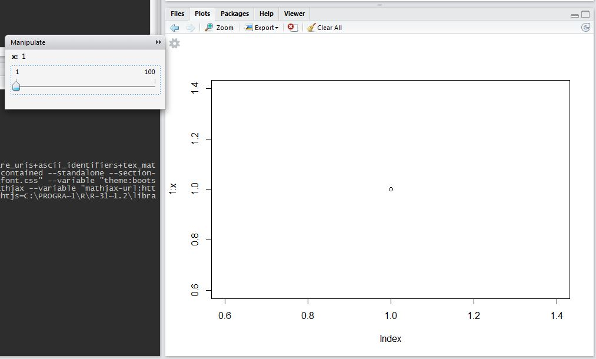

`plot`의 왼쪽 위에 보이는 설정버튼? 을 눌러보면 그림과 같은 창이 뜬다.

`x`변수의 초기값을 지정해주지는 않았지만 일단은 `x = 1`로 잡혀 있다

마우스로 슬라이더를 이동시켜서 아래 그림처럼 움직이면 차트도 함께 변하는 모습을 볼 수 있다.

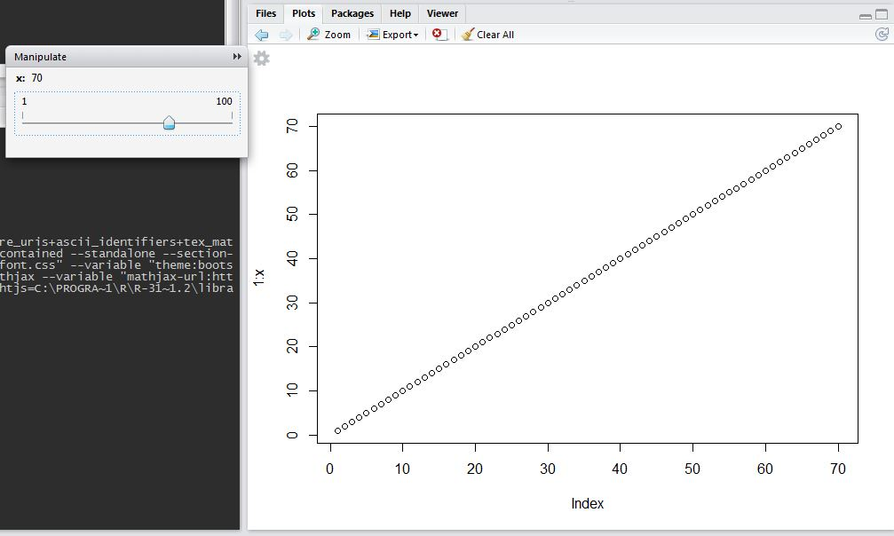

`manipulate`의 **Help Pages** 를 들어가보면 알겠지만 함수는 정말 몇개 없다

또 만들 수 있는 것이라고는 `버튼`, `체크박스`, `picker(드롭다운)`, `슬라이더` 네 개 정도 뿐이다.

하지만 덕분에 복잡하게 머리를 굴릴 필요도 없고

기존에 그리던 함수에 바로 적용가능하다는 점이 최대의 강점인 것 같다.

그러면 우리가 만들어 볼 수 있는 것들을 이용해서 차트를 그려보자

### Slider

```
manipulate(
  plot(cars, xlim=c(0,x.max)),
  x.max=slider(15,25, step = 5, initial = 20)
)
```

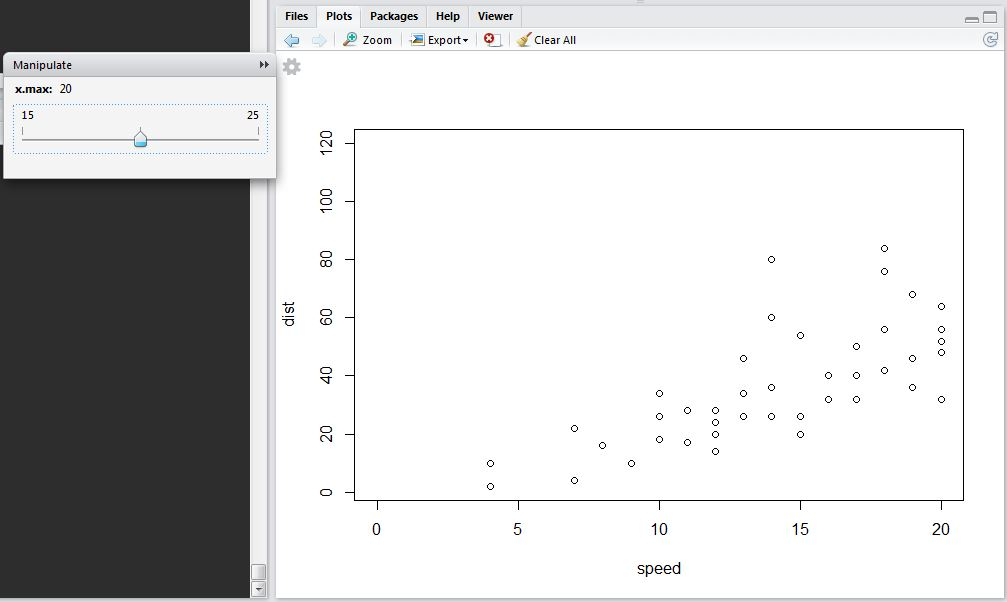

`steps`항목은 `slider`에서 선택가능한 항목간의 간격을 설정한다

`initial`은 `plot`이 그려질 때 변수의 초기값을 지정한다

### Picker

```
manipulate(
  barplot(as.matrix(longley[,factor]),
          beside = TRUE, main = factor),
  factor = picker("GNP", "Unemployed", "Employed")
)
```

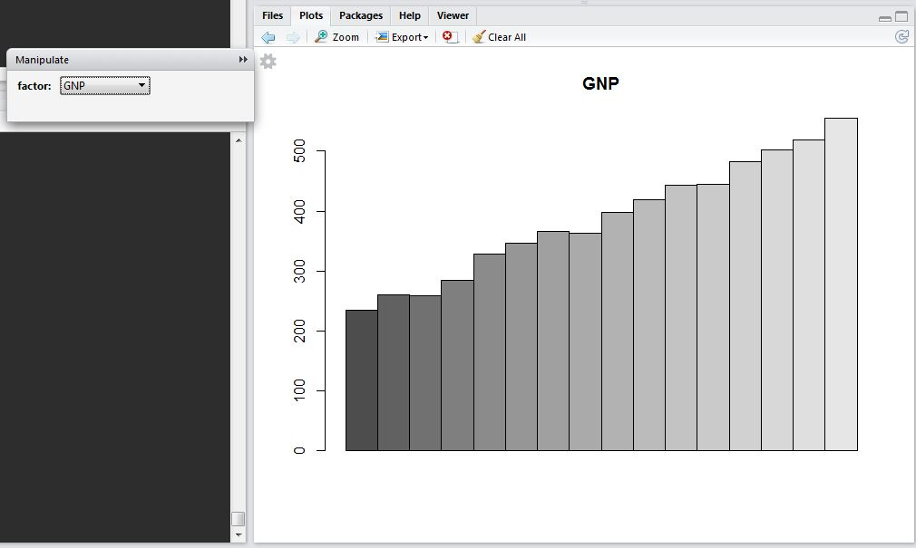

`picker` 함수 내부에 드랍다운으로 선택할 수 있는 항목들을 나열해주는 방식으로 사용한다

마찬가지로 `initial`옵션을 줄 수 있다.

위 `barplot`에서는 `picker`의 항목이 바뀌면 데이터와 `main(차트 제목)`이 변경된다

그리고 `manipulate()` 함수 내부에서 `barplot()`과 `factor = picker()`는 콤마(,)로 구분되어있다는 점에 주의!!

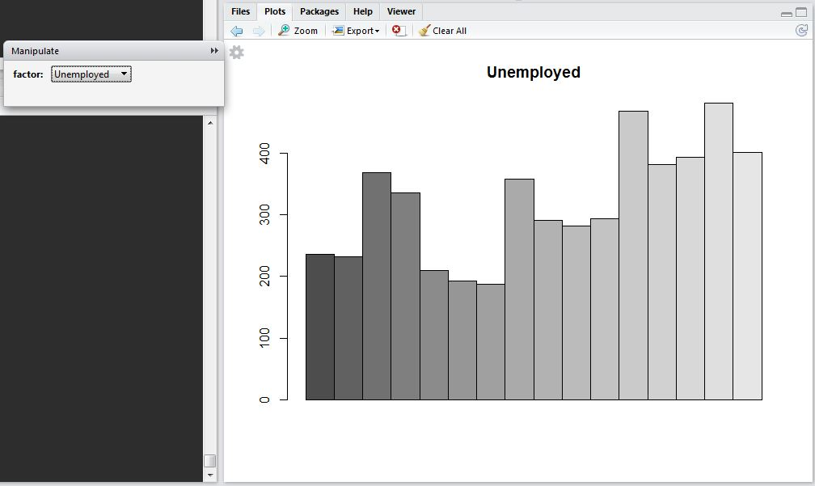

### Checkbox

```
manipulate(
  boxplot(Freq ~ Class, data = Titanic, outline = outline),
  outline = checkbox(FALSE, "Show outliers")
)
```

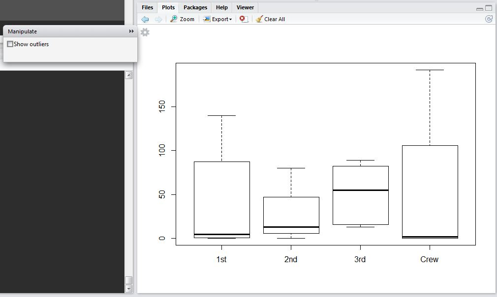

`checkbox` 항목은 어짜피 `TRUE/FALSE`이기 때문에 바로 `initial`항목을 정해주면 된다

위 차트에서는 `initial`값은 `FALSE`로 정하고 `label(체크박스 선택창에 표시될 내용)`을 `"show outliers"`로 지정했다

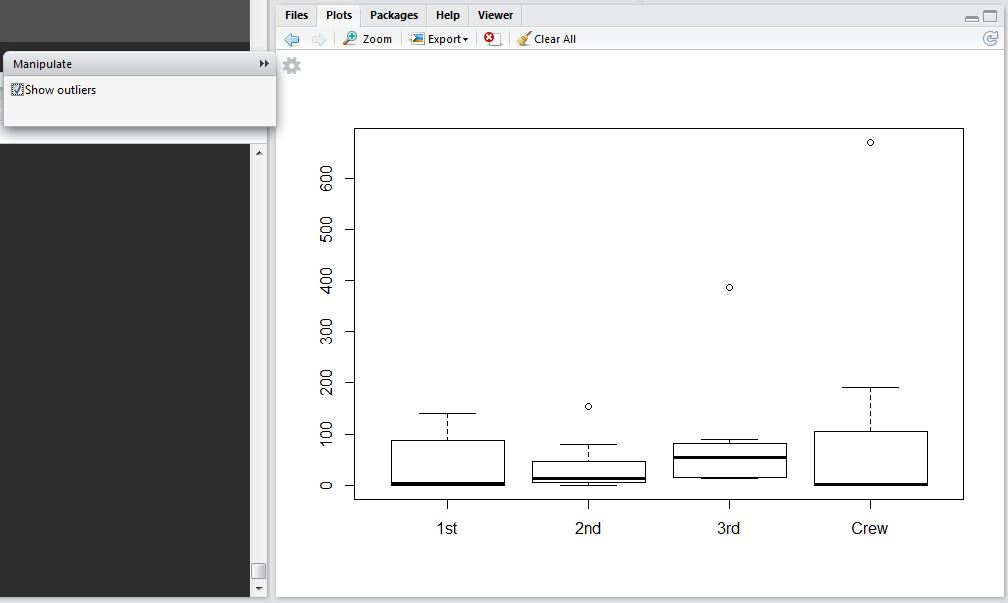

### Button

```
manipulate(
{
  if(resetSeed)
    set.seed(sample(1:1000))
  hist(rnorm(n=100, mean=0, sd=3), breaks=bins)
},
bins = slider(1, 20, step=1, initial =5, label="Bins"),
resetSeed = button("Reset Seed")
)
```

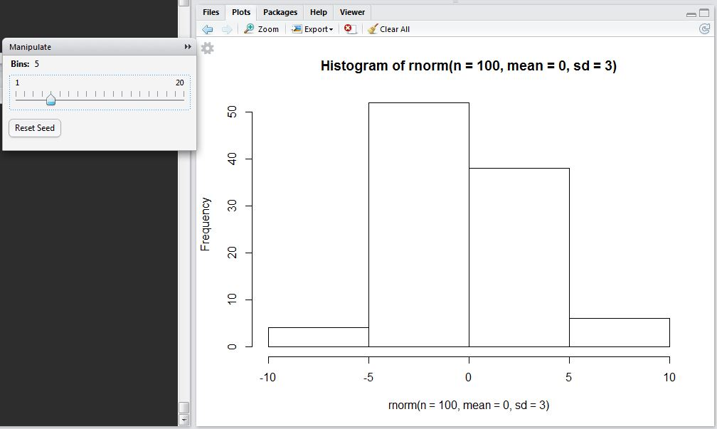

`button`항목에는 들어가는 항목이 `label`밖에 없다

위 차트의 경우 `resetSeed = button("Reset Seed")`으로 버튼을 생성하면

버튼을 클릭할 때 `resetSeed = TRUE`가 되어서 seed가 랜덤한 값으로 변경 된다

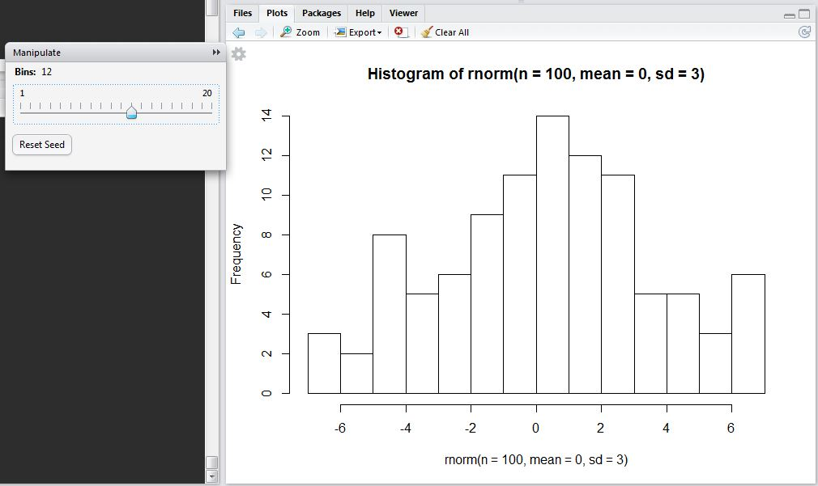

일단 슬라이더도 제대로 반영이 되었다.

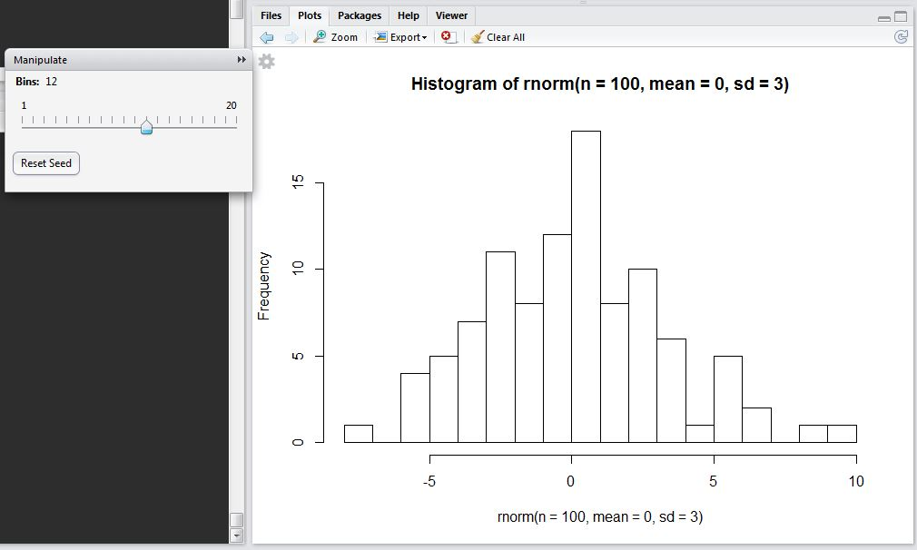

버튼을 클릭하면 seed가 변경되어서 히스토그램이 랜덤한 값으로 변경되는 것을 볼 수 있다

### Multiple Controls

```
manipulate(
  plot(cars, xlim = c(0, x.max), type = type, ann = label),
  x.max = slider(10, 25, step=5, initial = 25),
  type = picker("Points" = "p", "Line" = "l", "Step" = "s"),
  label = checkbox(TRUE, "Draw Labels"))
```

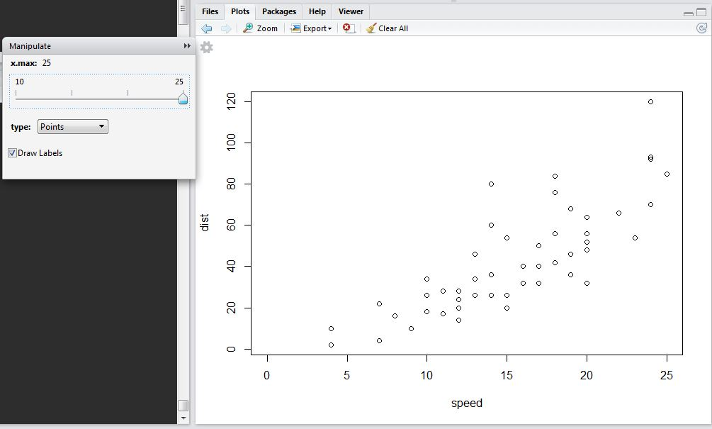

위에서 살펴본 다양한 함수들을 적용해 보았다

그러면 저런 기본 그래픽 함수들이 아니라 다른 패키지를 이용한 차트에도 적용할 수 있을까?

`ggplot2`패키지에 시도해보자

### ggplot2에 적용해보기

```
# install.packages("ggplot2") # 설치가 안되어있다면 실행
library(ggplot2)

manipulate(
  {plot_diamond <- ggplot(diamonds, aes_string(x= xvar, y= yvar))
  plot_diamond + geom_point()},
  xvar = picker("carat","cut", "color","clarity","depth","table","price","x","y","z", initial = "carat"),
  yvar = picker("carat", "depth", "table", "price", "x", "y", "z", initial = "price")
  )
```

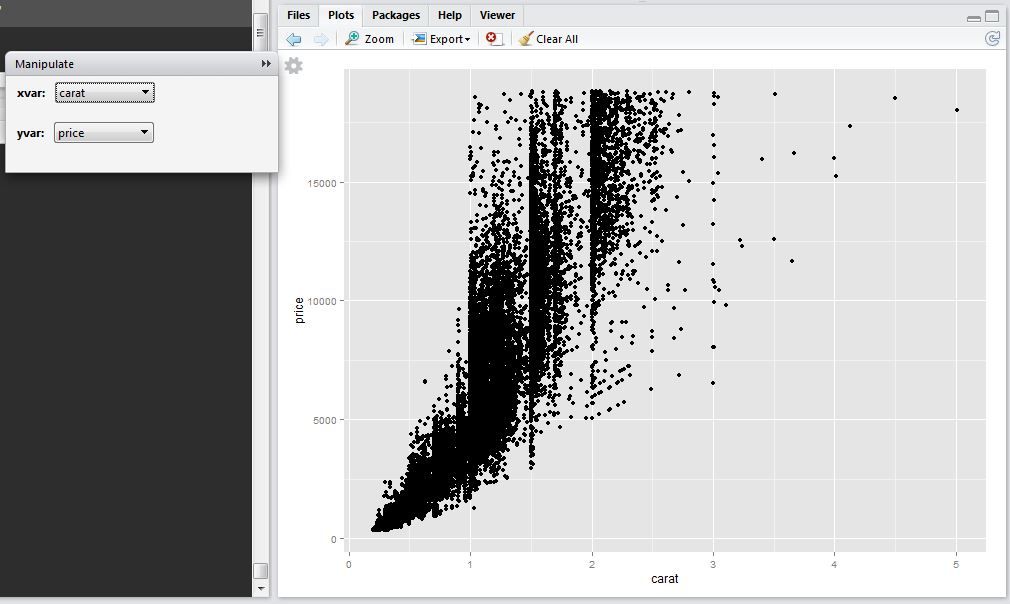

기존에 `ggplot2`를 써본 사람이라면 주의해야 할 점은

원래 `aes()`함수는 문자열이 아니라 오브젝트 이름처럼 열을 대했기 때문에 `aes(x = carat, y = price)`와 같은 형태로 구성했다.

그런데 `picker`함수에서 내보내는 값은 `"caret", "price"` 처럼 `""`로 감싸진 문자열이기 때문에 그냥 넣으면 실행이 되지 않는다

따라서 기존의 `aes()` 함수가 아니라 에스테틱을 문자열로 받아올 수 있는 `aes_string()` 함수를 이용해 차트를 구성해야 한다

그것만 주의한다면 위에서 했던 방식대로 `manipulate`패키지를 적용해 볼 수 있다.